# Coursera PML Course Project

Pankaj Goyal

Saturday, July 26, 2014

### Objective

The data was collected by Velloso, Bulling, Gellersen, Ugulino, and Fuks and their results presented in “Qualitative Activity Recognition of Weight Lifting Exercises.”; Proceedings of 4th International Conference in Cooperation with SIGCHI (Augmented Human ’13) ; Stuttgart, Germany: ACM SIGCHI, 2013.

The goal of this project is to predict the manner in which they did the exercise. They placed sensors on the arm, forearm, belt of the subjects and on dumbbell used.

### Analysis

The data provided to us was already splitted into a training and a test set. Training data is used to explore and develop a predictive model and used the final model on the test data to evaluate the results.

```r
# load the libraries
library(caret)
library(rattle)
library(gridExtra)
library(randomForest)
```

```r
# read the data
# training  <-  read.csv("pml-training.csv", header = T, strip.white = T, stringsAsFactors = F)
# testing   <-  read.csv("pml-testing.csv",  header = T, strip.white = T, stringsAsFactors = F)
training  <-  read.csv(url("http://d396qusza40orc.cloudfront.net/predmachlearn/pml-training.csv"), header = T, strip.white = T, stringsAsFactors = F)
testing   <-  read.csv(url("http://d396qusza40orc.cloudfront.net/predmachlearn/pml-testing.csv"),  header = T, strip.white = T, stringsAsFactors = F)
```

The data was imported as character in many cases and that is incorrect, and for now colums 6-159 should be numeric

```r
# dataset used: training
train     <-  training
charVar   <-  which(sapply(train,is.character))
train[charVar[4:36]]  <-  lapply(train[charVar[4:36]],as.numeric)
```

There is a lot of missing data, most varibles are either complete or missing, chose the ones with full data

```r
noNA      <-  which(sapply(train,function(x) sum(is.na(x)))==0)
noNA      <-  noNA[-(1:7)]
train_noNA<-  subset(train,,noNA)
```

I performed Principal Components Analysis, in order to reduce the number of features, dimensions and noise, on the set of measures for each sensor and then combined such measures in a new training set

```r
exercise  <-  c("_belt","_arm","_dumbbell","_forearm")

# create PC's for belt sensor
pc_belt   <-  preProcess(train_noNA[which(grepl(exercise[1], names(train_noNA)))], method = "pca")
pc_belt_new         <-  predict(pc_belt, train_noNA[which(grepl(exercise[1], names(train_noNA)))])
names(pc_belt_new)  <-  tolower(paste(names(pc_belt_new),exercise[1], sep = ""))

# create PC's for arm sensor
pc_arm    <-  preProcess(train_noNA[which(grepl(exercise[2], names(train_noNA)))], method = "pca")
pc_arm_new          <-  predict(pc_arm, train_noNA[which(grepl(exercise[2], names(train_noNA)))])
names(pc_arm_new)   <-  tolower(paste(names(pc_arm_new), exercise[2], sep = ""))

# create PC's for dumbbell sensor
pc_dumbbell <-  preProcess(train_noNA[which(grepl(exercise[3], names(train_noNA)))],method = "pca")
pc_dumbbell_new       <-  predict(pc_dumbbell, train_noNA[which(grepl(exercise[3], names(train_noNA)))])
names(pc_dumbbell_new)<-  tolower(paste(names(pc_dumbbell_new), exercise[3], sep = ""))

# create PC's for forearm sensor
pc_forearm  <-  preProcess(train_noNA[which(grepl(exercise[4], names(train_noNA)))], method = "pca")
pc_forearm_new        <-  predict(pc_forearm, train_noNA[which(grepl(exercise[4], names(train_noNA)))])
names(pc_forearm_new) <-  tolower(paste(names(pc_forearm_new), exercise[4], sep = ""))
```

Visual exploratory analysis of the data was performed by looking at the distributions by exercise class for each variable.

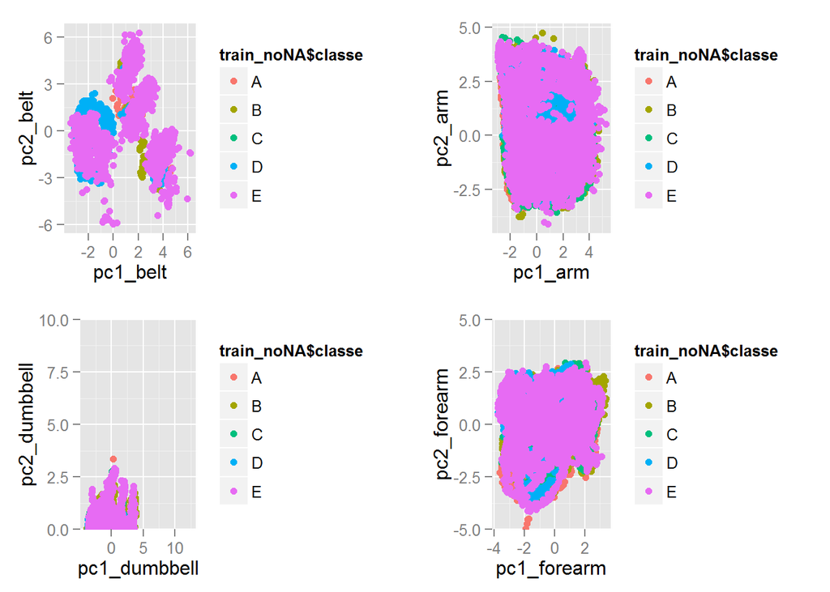

```r
# Visual exploratory analysis
p1  <-  ggplot(pc_belt_new, aes(x = pc1_belt, y = pc2_belt, color = train_noNA$classe)) + geom_point()
p2  <-  ggplot(pc_arm_new, aes(x = pc1_arm, y = pc2_arm, color = train_noNA$classe)) + geom_point()
p3  <-  ggplot(pc_dumbbell_new , aes(x = pc1_dumbbell, y = pc2_dumbbell, color = train_noNA$classe)) + geom_point() + coord_cartesian(ylim=c(0,10))
p4  <-  ggplot(pc_forearm_new, aes(x = pc1_forearm, y = pc2_forearm, color = train_noNA$classe)) + geom_point() + coord_cartesian(ylim=c(-5,5))
grid.arrange(p1, p2, p3, p4, nrow = 2, ncol = 2)
```

```r
# Combining all the PCs into one training PC Analysis set
training_pc   <-  data.frame(cbind(pc_belt_new, pc_arm_new, pc_dumbbell_new, pc_forearm_new), classe = train_noNA$classe)
```

Applying the PC’S to test dataset;

```r
test          <-  testing

# for belt sensor
test_pc_belt  <-  predict(pc_belt, newdata = test[row.names(pc_belt$rotation)])
names(test_pc_belt)   <-  tolower(paste(names(test_pc_belt), "_belt", sep = ""))

# for arm sensor
test_pc_arm   <-  predict(pc_arm, newdata = test[row.names(pc_arm$rotation)])
names(test_pc_arm)    <-  tolower(paste(names(test_pc_arm), "_arm", sep = ""))

# for dumbbell sensor
test_pc_dumbbell  <- predict(pc_dumbbell, newdata = test[row.names(pc_dumbbell$rotation)])
names(test_pc_dumbbell)<- tolower(paste(names(test_pc_dumbbell), "_dumbbell", sep = ""))

# for forearm sensor
test_pc_forearm   <- predict(pc_forearm, newdata = test[row.names(pc_forearm$rotation)])
names(test_pc_forearm)<-  tolower(paste(names(test_pc_forearm), "_forearm", sep = ""))

# Combining all the PCs into one testing PC Analysis set
testing_pc        <-  data.frame(cbind(test_pc_belt, test_pc_arm, test_pc_dumbbell, test_pc_forearm))
```

#### Prediction Models

- Model 1: Method (rpart): Due to its ease of interpretation, an attempt to model using a single CART tree using the caret package has made.

```r
set.seed(78786)
# MOdel 1: (rpart method)
model1  <-  train(classe ~ ., data = training_pc, method = "rpart")
# print the final model
model1$finalModel
```

```
## n= 19622
##
## node), split, n, loss, yval, (yprob)
##       * denotes terminal node
##
## 1) root 19622 14040 A (0.28 0.19 0.17 0.16 0.18)
##   2) pc3_dumbbell>=-0.2003 12876  8211 A (0.36 0.13 0.24 0.13 0.14) *
##   3) pc3_dumbbell< -0.2003 6746  4593 B (0.14 0.32 0.05 0.24 0.26)
##     6) pc4_dumbbell>=0.452 3431  2170 D (0.25 0.14 0.059 0.37 0.18) *
##     7) pc4_dumbbell< 0.452 3315  1642 B (0.018 0.5 0.041 0.1 0.34) *
```

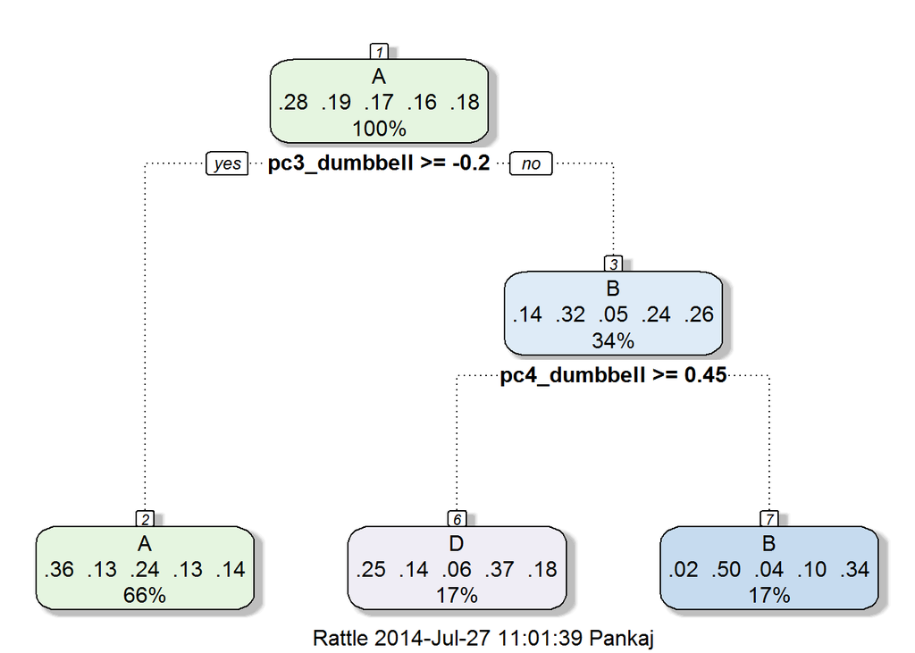

```r
# fancy rpart plotiing of the final model
fancyRpartPlot(model1$finalModel)
```

```r
# Confusion Matrix
confusionMatrix(predict(model1,training_pc),training_pc$classe)
```

```
## Confusion Matrix and Statistics
##
##           Reference
## Prediction    A    B    C    D    E
##          A 4665 1644 3082 1622 1863
##          B   59 1673  137  333 1113
##          C    0    0    0    0    0
##          D  856  480  203 1261  631
##          E    0    0    0    0    0
##
## Overall Statistics
##
##                Accuracy : 0.387
##                  95% CI : (0.38, 0.394)
##     No Information Rate : 0.284
##     P-Value [Acc > NIR] : <2e-16
##
##                   Kappa : 0.185
##  Mcnemar's Test P-Value : NA
##
## Statistics by Class:
##
##                      Class: A Class: B Class: C Class: D Class: E
## Sensitivity             0.836   0.4406    0.000   0.3921    0.000
## Specificity             0.415   0.8962    1.000   0.8677    1.000
## Pos Pred Value          0.362   0.5047      NaN   0.3675      NaN
## Neg Pred Value          0.864   0.8697    0.826   0.8793    0.816
## Prevalence              0.284   0.1935    0.174   0.1639    0.184
## Detection Rate          0.238   0.0853    0.000   0.0643    0.000
## Detection Prevalence    0.656   0.1689    0.000   0.1749    0.000
## Balanced Accuracy       0.626   0.6684    0.500   0.6299    0.500
```

But Unfortunately this was not successful as the resulting model did not predict 2 of the classes (C and E) and had very low accuracy of 38.7% and kappa of 18.5%.

- MOdel 2: Random Forest Method:

```r
set.seed(46776)
# Model2: Random Forest Method
model2      <-  randomForest(classe ~ ., data = training_pc)

# Confusion Matrix
confusionMatrix(predict(model2, training_pc), training_pc$classe)
```

```
## Confusion Matrix and Statistics
##
##           Reference
## Prediction    A    B    C    D    E
##          A 5580    0    0    0    0
##          B    0 3797    0    0    0
##          C    0    0 3422    0    0
##          D    0    0    0 3216    0
##          E    0    0    0    0 3607
##
## Overall Statistics
##
##                Accuracy : 1
##                  95% CI : (1, 1)
##     No Information Rate : 0.284
##     P-Value [Acc > NIR] : <2e-16
##
##                   Kappa : 1
##  Mcnemar's Test P-Value : NA
##
## Statistics by Class:
##
##                      Class: A Class: B Class: C Class: D Class: E
## Sensitivity             1.000    1.000    1.000    1.000    1.000
## Specificity             1.000    1.000    1.000    1.000    1.000
## Pos Pred Value          1.000    1.000    1.000    1.000    1.000
## Neg Pred Value          1.000    1.000    1.000    1.000    1.000
## Prevalence              0.284    0.194    0.174    0.164    0.184
## Detection Rate          0.284    0.194    0.174    0.164    0.184
## Detection Prevalence    0.284    0.194    0.174    0.164    0.184
## Balanced Accuracy       1.000    1.000    1.000    1.000    1.000
```

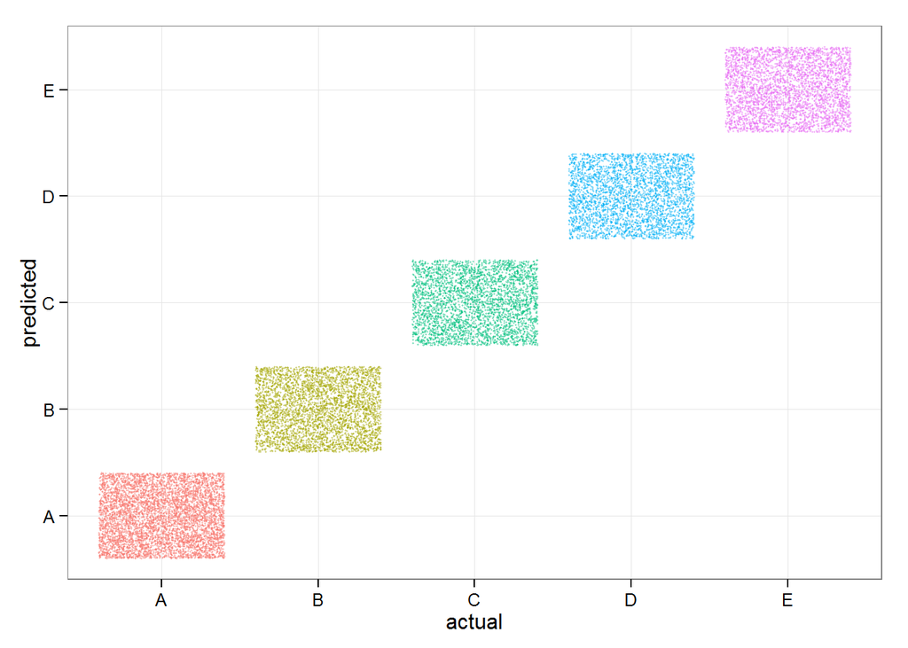

```r
# Plot
results_rf  <-  data.frame(actual = training_pc$classe, predicted = predict(model2, training_pc))
ggplot(results_rf, aes(x = actual, y = predicted, color = actual)) + geom_jitter(size = 0.5, alpha = 0.5) + theme_bw() + theme(legend.position = "none")
```

Applying the model to test set,

```r
#predict and generate the cases for evaluation
testing_predict   <-  predict(model2, testing_pc)

# change the working directory
setwd("/Users/Pankaj/pml_CourseProject/predictions/")
source("/Users/Pankaj/pml_CourseProject/pml_write_files.R")
pml_write_files(testing_predict)
```

The interpretation of the meaning of principal components is always challenging. In this case it is more so given that the measurements of the sensors deal with concepts not very familiar to most people (yaw, roll, pitch).